# Anime

Mendoza Díaz Citlali

Peña Romero Gerardo

Ramírez Pérez Gerardo Enrique

Vásquez Rodríguez Iván

Galindez Vergara Guillermo Anibal

2026-09-30

## Contexto del Problema

La industria del anime ha pasado de ser un nicho de entretenimiento a un fenómeno global masivo. Sin embargo, la clasificación tradicional basada únicamente en géneros temáticos es insuficiente para entender el comportamiento de la audiencia. Comprender las dimensiones ocultas del éxito de una serie permite a las plataformas de streaming mitigar riesgos de inversión y optimizar estrategias de adquisición de licencias.

**Audiencia del proyecto:** Analistas de contenido, gerentes de adquisición y estrategas de plataformas de entretenimiento digital.

## Pregunta de Investigación

¿Se pueden identificar agrupaciones (clústeres) ocultas de anime basándonos en la relación entre su formato, sus géneros principales y su impacto en la audiencia (popularidad y calificación)?

### Documentación de la Fuente y Población

- **Fuente de Datos:** Debido a intermitencias de estabilidad en los servidores de la API de AniList (GraphQL) durante la fase de recolección, se utilizó un *snapshot* estático de la base de datos alojado en Kaggle. Esto garantiza la reproducibilidad del análisis.
- **Población y Muestra:** El universo consta de 20,425 registros. La muestra efectiva para el modelado excluirá a las observaciones sin calificación o popularidad, ya que imposibilitan medir su impacto real.

Para demostrar la capacidad técnica de conexión en vivo y validar la estructura original, se presenta una prueba de concepto conectando a la API de AniList vía GraphQL para extraer los 5 animes más populares. Para el resto del modelado, se utilizará el *snapshot* en CSV para evitar bloqueos por límites de peticiones (Rate Limits) en extracciones masivas.

```r
library(httr)
library(jsonlite)

# Prueba de concepto: Conexión a API GraphQL
query <- '
query {
  Page(page: 1, perPage: 5) {
    media(type: ANIME, sort: POPULARITY_DESC) {
      id
      title { romaji }
      format
      episodes
      averageScore
      popularity
    }
  }
}
'
respuesta <- POST("https://graphql.anilist.co", body = list(query = query), encode = "json")

if (status_code(respuesta) == 200) {
  datos_api <- fromJSON(content(respuesta, as = "text", encoding = "UTF-8"), flatten = TRUE)
  knitr::kable(datos_api$data$Page$media, caption = "Prueba de Conexión: Top 5 API AniList")
} else {
  print("La API de AniList se encuentra en mantenimiento temporal.")
}
```

Prueba de Conexión: Top 5 API AniList

| id | format | episodes | averageScore | popularity | title.romaji |
| --- | --- | --- | --- | --- | --- |
| 16498 | TV | 25 | 85 | 1060412 | Shingeki no Kyojin |
| 101922 | TV | 26 | 82 | 999342 | Kimetsu no Yaiba |
| 113415 | TV | 24 | 84 | 978315 | Jujutsu Kaisen |
| 1535 | TV | 37 | 84 | 967047 | DEATH NOTE |
| 21459 | TV | 13 | 76 | 878181 | Boku no Hero Academia |

```r
# Cargamos las librerías necesarias para la limpieza de datos
library(dplyr)

# Leemos el archivo CSV y lo guardamos en un Data Frame llamado "df_anime"
# El parámetro stringsAsFactors = FALSE evita que R convierta los textos en categorías automáticamente por ahora
anime <- read.csv("anilist_anime.csv", stringsAsFactors = FALSE)

# Primer vistazo a la estructura de la base de datos
print("¡Archivo cargado con éxito! Aquí están las dimensiones (filas y columnas):")
```

```
## [1] "¡Archivo cargado con éxito! Aquí están las dimensiones (filas y columnas):"
```

```r
print(dim(anime))
```

```
## [1] 20425    62
```

```r
print("Nombres de las columnas disponibles:")
```

```
## [1] "Nombres de las columnas disponibles:"
```

```r
print(names(anime))
```

```
##  [1] "X"                        "id"                       "idMal"
##  [4] "title_romaji"             "title_english"            "title_native"
##  [7] "title_userPreferred"      "type"                     "format"
## [10] "status"                   "description"              "startDate_year"
## [13] "startDate_month"          "startDate_day"            "endDate_year"
## [16] "endDate_month"            "endDate_day"              "season"
## [19] "seasonYear"               "seasonInt"                "episodes"
## [22] "duration"                 "chapters"                 "volumes"
## [25] "countryOfOrigin"          "isLicensed"               "source"
## [28] "hashtag"                  "trailer_id"               "trailer_site"
## [31] "trailer_thumbnail"        "updatedAt"                "coverImage_extraLarge"
## [34] "coverImage_large"         "coverImage_medium"        "coverImage_color"
## [37] "bannerImage"              "genres"                   "synonyms"
## [40] "tags"                     "averageScore"             "meanScore"
## [43] "popularity"               "favourites"               "trending"
## [46] "rankings"                 "isFavourite"              "isAdult"
## [49] "isLocked"                 "siteUrl"                  "externalLinks"
## [52] "streamingEpisodes"        "relations"                "characters"
## [55] "staff"                    "studios"                  "nextAiringEpisode"
## [58] "airingSchedule"           "recommendations"          "reviews"
## [61] "stats_scoreDistribution"  "stats_statusDistribution"
```

```r
# Revisamos los primeros 5 registros
head(anime)
```

```
##   X   id idMal                 title_romaji              title_english          title_native
## 1 0 1497  1497 Aru Machi Kado no Monogatari Tales of the Street Corner        ある街角の物語
## 2 1 1547  1547             Obake no Q-tarou                            オバQ; オバケのＱ太郎
## 3 2 1572  1572                Jungle Taitei       Kimba the White Lion        ジャングル大帝
## 4 3 1982  1982                          Osu                       Male                  おす
## 5 4 1984  1984                       Memory                                         めもりい
## 6 5 1989  1989                      Shizuku                   The Drop                しずく
##            title_userPreferred  type format   status
## 1 Aru Machi Kado no Monogatari ANIME  MOVIE FINISHED
## 2             Obake no Q-tarou ANIME     TV FINISHED
## 3                Jungle Taitei ANIME     TV FINISHED
## 4                          Osu ANIME  MOVIE FINISHED
## 5                       Memory ANIME  MOVIE FINISHED
## 6                      Shizuku ANIME  MOVIE FINISHED
##                                                                                                                                                                                                                                                                                                          …
```

[output cut: 174 more lines]

```r
# Para ver la estructura, las columnas y el tipo de dato
str(anime)
```

```
## 'data.frame':    20425 obs. of  62 variables:
##  $ X                       : int  0 1 2 3 4 5 6 7 8 9 ...
##  $ id                      : int  1497 1547 1572 1982 1984 1989 2047 2686 2747 2765 ...
##  $ idMal                   : num  1497 1547 1572 1982 1984 ...
##  $ title_romaji            : chr  "Aru Machi Kado no Monogatari" "Obake no Q-tarou" "Jungle Taitei" "Osu" ...
##  $ title_english           : chr  "Tales of the Street Corner" "" "Kimba the White Lion" "Male" ...
##  $ title_native            : chr  "ある街角の物語" "オバQ; オバケのＱ太郎" "ジャングル大帝" "おす" ...
##  $ title_userPreferred     : chr  "Aru Machi Kado no Monogatari" "Obake no Q-tarou" "Jungle Taitei" "Osu" ...
##  $ type                    : chr  "ANIME" "ANIME" "ANIME" "ANIME" ...
##  $ format                  : chr  "MOVIE" "TV" "TV" "MOVIE" ...
##  $ status                  : chr  "FINISHED" "FINISHED" "FINISHED" "FINISHED" ...
##  $ description             : chr  "The scene is set with a poster on a street corner, a girl who cherishes her teddy bear, a street lamp and a pla"| __truncated__ "Q-taro, a monster, is living with the Ohara family. He can fly and make his body transparent, but he cannot tur"| __truncated__ "The …
##  $ startDate_year          : int  1962 1965 1965 1962 1964 1965 1964 1963 1963 1945 ...
##  $ startDate_month         : num  11 8 10 11 9 10 9 10 1 4 ...
##  $ startDate_day           : num  5 29 6 5 21 1 21 20 1 12 ...
```

[output cut: 48 more lines]

```r
# Construimos el Diccionario de Datos
diccionario_anime <- data.frame(
  Columna = names(anime),
  Tipo = sapply(anime, class),

  # Calculamos el porcentaje de "basura" o nulos reales
  # (Consideramos NA, textos en blanco "", y listas vacías "[]")
  Pct_Vacios = sapply(anime, function(x) {
    round(sum(is.na(x) | x == "" | x == "[]") / length(x) * 100, 2)
  }),

  # Extraemos el primer valor como ejemplo para saber qué contiene
  Ejemplo = sapply(anime, function(x) as.character(x[1])),

  stringsAsFactors = FALSE
) |>
  # Ordenamos de las columnas más vacías a las más llenas
  arrange(desc(Pct_Vacios))

# Desplegamos la tabla
knitr::kable(head(diccionario_anime, 10))
```

|  | Columna | Tipo | Pct_Vacios | Ejemplo |
| --- | --- | --- | --- | --- |
| chapters | chapters | logical | 100.00 | NA |
| volumes | volumes | logical | 100.00 | NA |
| nextAiringEpisode | nextAiringEpisode | character | 99.89 |  |
| streamingEpisodes | streamingEpisodes | character | 86.27 | [] |
| reviews | reviews | character | 82.12 | [] |
| hashtag | hashtag | character | 78.35 |  |
| airingSchedule | airingSchedule | character | 76.24 | [] |
| bannerImage | bannerImage | character | 63.72 | https://s4.anilist.co/file/anilistcdn/media/anime/banner/1497-qivayRHBmgOZ.jpg |
| trailer_id | trailer_id | character | 62.74 |  |
| trailer_site | trailer_site | character | 62.74 |  |

## Limpieza y Transformación de Datos

**Exploración Inicial y Dimensiones del Conjunto de Datos** El análisis partió de una base de datos original extraída en formato CSV que consta de 20,425 registros (observaciones) y 62 variables. Para garantizar la calidad y representatividad del modelo de clustering, se realizó una auditoría estructural inicial creando un Diccionario de Datos, lo que permitió evaluar el porcentaje de valores atípicos, nulos (NA) y el tipo de estructura de cada variable.

**Criterios de Exclusión y Reducción de Dimensionalidad** Para evitar introducir ruido estadístico y sesgos en el algoritmo matemático, se aplicaron los siguientes criterios de exclusión de variables:

-Alta Faltabilidad (Valores Nulos): Se eliminaron aquellas columnas que presentaban un porcentaje crítico de datos faltantes, listas vacías ([]) o cadenas de texto en blanco. Imputar estadísticamente estas variables habría comprometido la integridad del análisis.

-Variables de Metadatos y Sistema: Se excluyeron identificadores internos (idMal), enlaces externos (siteUrl, externalLinks), fechas de actualización (updatedAt) y referencias a imágenes (coverImage, bannerImage). Estos datos representan ruido técnico que no aporta varianza matemática para la categorización del anime.

-Información Redundante: Variables como title_english o title_native fueron descartadas en favor de conservar únicamente title_romaji como identificador principal estandarizado.

## Selección de Variables Específicas (Núcleo Analítico)

Acorde a la pregunta de investigación orientada a descubrir tipologías ocultas según la popularidad y las características de las series, el modelo conservó exclusivamente las variables con mayor densidad de información:

-averageScore y popularity: Como métricas continuas de rendimiento y recepción del público.

-format y episodes: Como características estructurales de la obra.

-genres: Como principal categorizador temático.

```r
# Seleccionamos el núcleo analítico y exportamos la base ligera para subir a GitHub
df_base_ligera <- anime |>
  select(
    id,
    title_romaji,
    format,
    episodes,
    averageScore,
    popularity,
    genres
  )

saveRDS(df_base_ligera, "df_anime_reducido.rds")
print("Archivo 'df_anime_reducido' generado exitosamente.")
```

```
## [1] "Archivo 'df_anime_reducido' generado exitosamente."
```

## Transformación y Limpieza de Cadenas (Data Wrangling)

Durante la exploración se detectó que las variables categóricas clave, como los géneros (genres), se encontraban anidadas bajo una sintaxis heredada de formato JSON (ej. [“Drama”, “Fantasy”]). Para permitir que el modelo interpretara estas características correctamente, se aplicaron técnicas de expresiones regulares (Regex) para limpiar los caracteres especiales (corchetes y comillas), estandarizando el texto y preparándolo para la posterior creación de variables dummy (One-Hot Encoding). Finalmente, se eliminaron los registros puntuales que no contaban con una calificación registrada (averageScore), ya que representaban un valor faltante imposible de evaluar para el objetivo principal de este análisis.

```r
library(dplyr)
library(stringr)

anime_crudo <- readRDS("df_anime_reducido.rds")

#Creamos la base de datos limpia aplicando transformaciones
anime_limpio <- anime_crudo |>

  # Limpiamos la columna de géneros de los caracteres extraños (JSON)
  mutate(
    genres_limpio = str_replace_all(genres, "[\\[\\]\\\"\\\\]", ""),
    genres_limpio = ifelse(genres_limpio == "", NA, genres_limpio)
  ) |>

  # Borramos la columna 'genres' sucia original y conservamos solo la limpia
  select(-genres) |>

  # Filtramos los registros que carecen de calificación o de género
  filter(!is.na(averageScore) & !is.na(genres_limpio))

# Comprobamos las dimensiones finales (filas y columnas)
cat("Dimensiones de la base limpia:", dim(anime_limpio), "\n\n")
```

```
## Dimensiones de la base limpia: 14931 7
```

```r
# Desplegamos la tabla transformada para el reporte
knitr::kable(head(anime_limpio, 10))
```

| id | title_romaji | format | episodes | averageScore | popularity | genres_limpio |
| --- | --- | --- | --- | --- | --- | --- |
| 1497 | Aru Machi Kado no Monogatari | MOVIE | 1 | 62 | 2210 | Drama, Fantasy, Music, Romance |
| 1547 | Obake no Q-tarou | TV | 96 | 57 | 467 | Comedy |
| 1572 | Jungle Taitei | TV | 52 | 61 | 2671 | Adventure |
| 1982 | Osu | MOVIE | 1 | 46 | 1413 | Slice of Life |
| 1984 | Memory | MOVIE | 1 | 54 | 1253 | Mystery |
| 1989 | Shizuku | MOVIE | 1 | 50 | 1084 | Comedy |
| 2047 | Ningyo | MOVIE | 1 | 57 | 1580 | Fantasy |
| 2686 | Tetsujin 28-gou | TV | 83 | 58 | 1617 | Adventure, Mecha, Sci-Fi |
| 2747 | Tetsuwan Atom | TV | 193 | 65 | 4540 | Action, Adventure, Drama, Mecha, Sci-Fi |
| 2765 | Momotarou: Umi no Shinpei | MOVIE | 1 | 46 | 1337 | Action |

# Verificación

Una vez recibida la base depurada, se procedió a una auditoría técnica para garantizar que las variables numéricas esté correctamente tipadas. En este paso se fuerza la conversión de `episodes`,`averageScore` y `popularity` a tipo numérico, yse trata a `format` como variable categórica. Adicionalmente, se revisan los rangos de cada variable para detectar valores imposibles que podrían sesgar.

```r
library(tidyr)
library(ggplot2)
library(forcats)
library(scales)
library(knitr)
library(corrplot)

#Tipos correctos (vienen como character del CSV)
anime_limpio <- anime_limpio |>
  mutate(
    episodes     = as.numeric(episodes),
    averageScore = as.numeric(averageScore),
    popularity   = as.numeric(popularity),
    format       = as.factor(format)
  )

# Control de rangos
summary(anime_limpio |> select(episodes, averageScore, popularity))
```

```
##     episodes        averageScore     popularity
##  Min.   :   1.00   Min.   :16.00   Min.   :    107
##  1st Qu.:   1.00   1st Qu.:53.00   1st Qu.:    758
##  Median :   3.00   Median :61.00   Median :   2337
##  Mean   :  12.46   Mean   :60.76   Mean   :  20159
##  3rd Qu.:  12.00   3rd Qu.:69.00   3rd Qu.:  11567
##  Max.   :1818.00   Max.   :91.00   Max.   :1051019
##  NAs    :97
```

# Duplicables

Antes de avanzar, se verifica la existencia de registros repetidos, ya que la presencia de duplicados infla artificialmente las frecuencias y distorsiona tanto las medias como los algoritmos de agrupamiento. Se detectaron duplicados bajo dos criterios: por identificación único (`id`) y por título estandarizado (`title_romaji`). En lo casos detectados se conservó el registro con mayor popularidad, por representar la entrada más consolidada y reconocida por la audiencia. Esta decisión evita que una misma obra aparezca dos veces en el análisis.

```r
cat("Duplicados por id:",           sum(duplicated(anime_limpio$id)), "\n")
```

```
## Duplicados por id: 0
```

```r
cat("Duplicados por title_romaji:", sum(duplicated(anime_limpio$title_romaji)), "\n")
```

```
## Duplicados por title_romaji: 32
```

```r
anime_limpio <- anime_limpio |>
  arrange(desc(popularity)) |>
  distinct(id, .keep_all = TRUE) |>
  distinct(title_romaji, .keep_all = TRUE)

cat("Dimensiones tras eliminar duplicados:", dim(anime_limpio), "\n")
```

```
## Dimensiones tras eliminar duplicados: 14899 7
```

# Tipo de Variables

Con el fin de documentar la naturaleza de cada variable y justificar las decisiones metodológica, se elabroró una clasificación en dos niveles. El primero describe el tipo técnico en R. El segundo describe el tipo estadístico: nominal, discreta, continua o multivaluada. Esta clasificación es relevante porque determina qué operaciones son válidas para cada variable y qué transformaciones se requieren antes de aplicar modelos matemáticos como el clustering.

```r
tipos_r <- data.frame(
  Variable = names(anime_limpio),
  Tipo_R   = sapply(anime_limpio, function(x) class(x)[1]),
  Ejemplo  = sapply(anime_limpio, function(x) as.character(x[1]))
)
kable(tipos_r, caption = "Tipos de variables en anime_limpio")
```

Tipos de variables en anime_limpio

|  | Variable | Tipo_R | Ejemplo |
| --- | --- | --- | --- |
| id | id | integer | 16498 |
| title_romaji | title_romaji | character | Shingeki no Kyojin |
| format | format | factor | TV |
| episodes | episodes | numeric | 25 |
| averageScore | averageScore | numeric | 85 |
| popularity | popularity | numeric | 1051019 |
| genres_limpio | genres_limpio | character | Action, Drama, Fantasy, Mystery |

```r
clasificacion <- data.frame(
  Variable   = c("format","episodes","averageScore","popularity","genres_limpio"),
  Tipo_estad = c("Nominal","Discreta","Continua","Continua","Multivaluada"),
  Rol_modelo = c("Feature (dummy)","Feature","Feature/Target",
                 "Feature/Target","Feature (dummies)")
)
kable(clasificacion, caption = "Clasificación conceptual de variables")
```

Clasificación conceptual de variables

| Variable | Tipo_estad | Rol_modelo |
| --- | --- | --- |
| format | Nominal | Feature (dummy) |
| episodes | Discreta | Feature |
| averageScore | Continua | Feature/Target |
| popularity | Continua | Feature/Target |
| genres_limpio | Multivaluada | Feature (dummies) |

# Transformaciones

La varibale de popularidad presenta una distribución altamente asimétrica: unas pocas series concentran millones de seguidores mientras que la mayoría apenas alcanza cifras modestas. esta seimetría distorsiona medidas y perjudica a los algoritmos basados en distancias, que otorgan el mismo peso a diferencias absolutas son considerar la escala. Para corregir este problema se aplicó una transformación logarítmica (`log1p`), que comprime los valores extremos y aproxima la distribución a una forma más simétrica. Complementariamente, las variables destinadas al modelo de clustering fueron estandarizadas para que todas contribuyan en igual proporción, y `averageScore` fue reescalado al rango [0,1].

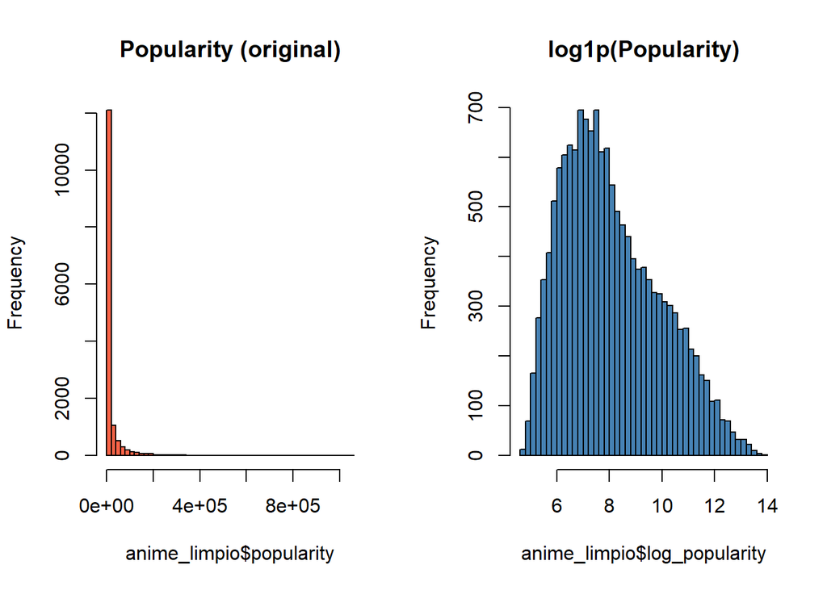

```r
anime_limpio <- anime_limpio |>
  mutate(
    log_popularity = log1p(popularity),
    log_episodes   = log1p(episodes),
    score_norm     = (averageScore - min(averageScore)) /
                     (max(averageScore) - min(averageScore)),
    pop_z          = as.numeric(scale(log_popularity)),
    score_z        = as.numeric(scale(averageScore))
  )

par(mfrow = c(1,2))
hist(anime_limpio$popularity,     main = "Popularity (original)", breaks = 40, col = "tomato")
hist(anime_limpio$log_popularity, main = "log1p(Popularity)",     breaks = 40, col = "steelblue")
```

```r
par(mfrow = c(1,1))
```

# Variables derivadas

```r
anime_limpio <- anime_limpio |>
  mutate(
    tipo_duracion = case_when(
      episodes == 1   ~ "Película/OVA",
      episodes <= 13  ~ "Corta (1 cour)",
      episodes <= 26  ~ "Media (2 cours)",
      episodes <= 100 ~ "Larga",
      TRUE            ~ "Muy larga"
    ),
    tipo_duracion = factor(tipo_duracion,
      levels = c("Película/OVA","Corta (1 cour)","Media (2 cours)","Larga","Muy larga")),

    cat_score = case_when(
      averageScore >= 80 ~ "Excelente",
      averageScore >= 70 ~ "Bueno",
      averageScore >= 60 ~ "Regular",
      TRUE               ~ "Bajo"
    ),
    cat_score = factor(cat_score, levels = c("Bajo","Regular","Bueno","Excelente")),

    cat_popularidad = ntile(popularity, 4) |>
      factor(labels = c("Baja","Media-Baja","Media-Alta","Alta")),

    n_generos = str_count(genres_limpio, ",") + 1,

    ratio_score_pop = averageScore / log_popularity
  )
```

# One Hot Encoding (generos y formato)

Los algoritmos de agrupamiento como K-Means operan sobre distancias numéricas, por lo que las variables categóricas y multivaluadas deben transformarse en representaciones binarias antes de ingresar al modelo. Se aplicó One-Hot Encoding a `format` y a la lista de géneros: cada categoría se convierte en una columna con valores 0 o 1 que indican la pertenencia o no de cada anime a esa categoría. Este procedimiento permite que el algoritmo trate a los géneros como dimensiones independientes sin imponer una jerarquía artificial entre ellos.

```r
# Dummies de FORMATO
dummies_format <- model.matrix(~ format - 1, data = anime_limpio) |>
  as.data.frame()
colnames(dummies_format) <- paste0("fmt_", gsub("format", "", colnames(dummies_format)))
dummies_format$id <- anime_limpio$id

# Dummies de géneros (usando genres_limpio)
anime_gen_long <- anime_limpio |>
  separate_rows(genres_limpio, sep = ",\\s*") |>
  rename(genero = genres_limpio) |>
  filter(genero != "")

dummies_gen <- anime_gen_long |>
  mutate(valor = 1) |>
  pivot_wider(names_from = genero, values_from = valor,
              values_fill = 0, id_cols = id)

# Unión al df principal
anime_limpio <- anime_limpio |>
  left_join(dummies_format, by = "id") |>
  left_join(dummies_gen,    by = "id") |>
  mutate(across(where(is.numeric), ~replace_na(.x, 0)))

cat("Dimensiones tras One-Hot Encoding:", dim(anime_limpio), "\n")
```

```
## Dimensiones tras One-Hot Encoding: 14899 44
```

# Estadística descriptiva

Se calcularon las principales medidas de tendencia central, dispersión y posición de las variables numéricas, lo cual permite caracterizar el catálogo en términos generales. La matriz de correlaciones, por su parte, cuantifica el grado de asociación lineal entre variables y constituye la primera evidencia formal sobre una de las hipótesis centrales del proyecto: si la popularidad de una serie está o no alineada con su calidad percibida por la audiencia.

```r
vars_num <- anime_limpio |>
  select(episodes, averageScore, popularity,
         log_popularity, n_generos, ratio_score_pop)

resumen <- data.frame(
  Variable = names(vars_num),
  Media    = sapply(vars_num, mean,   na.rm = TRUE),
  Mediana  = sapply(vars_num, median, na.rm = TRUE),
  SD       = sapply(vars_num, sd,     na.rm = TRUE),
  Min      = sapply(vars_num, min,    na.rm = TRUE),
  Q1       = sapply(vars_num, quantile, 0.25, na.rm = TRUE),
  Q3       = sapply(vars_num, quantile, 0.75, na.rm = TRUE),
  Max      = sapply(vars_num, max,    na.rm = TRUE)
) |> mutate(across(where(is.numeric), ~round(.x, 2)))

kable(resumen, caption = "Estadística descriptiva")
```

Estadística descriptiva

|  | Variable | Media | Mediana | SD | Min | Q1 | Q3 | Max |
| --- | --- | --- | --- | --- | --- | --- | --- | --- |
| episodes | episodes | 12.38 | 3.00 | 38.36 | 0.00 | 1.00 | 12.00 | 1818.00 |
| averageScore | averageScore | 60.77 | 61.00 | 10.91 | 16.00 | 53.00 | 69.00 | 91.00 |
| popularity | popularity | 20196.49 | 2347.00 | 59701.85 | 107.00 | 760.00 | 11615.50 | 1051019.00 |
| log_popularity | log_popularity | 8.08 | 7.76 | 1.84 | 4.68 | 6.63 | 9.36 | 13.87 |
| n_generos | n_generos | 2.47 | 2.00 | 1.28 | 1.00 | 1.00 | 3.00 | 9.00 |
| ratio_score_pop | ratio_score_pop | 7.68 | 7.66 | 1.18 | 1.68 | 6.88 | 8.41 | 12.12 |

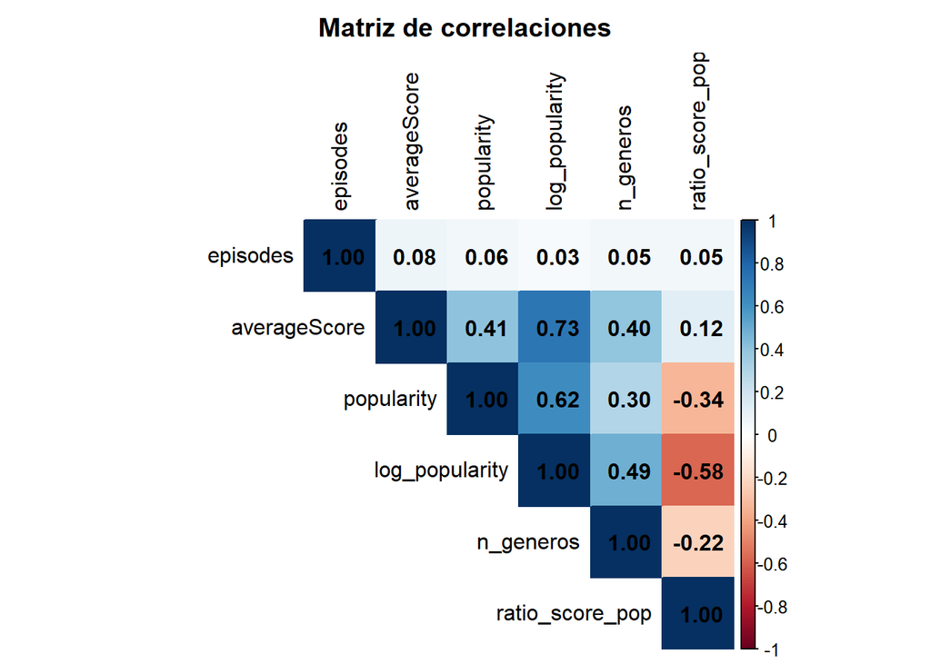

```r
cor_mat <- cor(vars_num, use = "complete.obs")
corrplot(cor_mat, method = "color", type = "upper",
         addCoef.col = "black", tl.col = "black",
         title = "Matriz de correlaciones", mar = c(0,0,2,0))
```

# Exploración: géneros, formatos, popularidad, rating

```r
# Formatos
anime_limpio |>
  count(format, sort = TRUE) |>
  mutate(pct = round(n / sum(n) * 100, 2)) |>
  kable(caption = "Distribución por formato")
```

Distribución por formato

| format | n | pct |
| --- | --- | --- |
| TV | 4281 | 28.73 |
| OVA | 3507 | 23.54 |
| MOVIE | 2239 | 15.03 |
| ONA | 2079 | 13.95 |
| SPECIAL | 1446 | 9.71 |
| TV_SHORT | 766 | 5.14 |
| MUSIC | 580 | 3.89 |
|  | 1 | 0.01 |

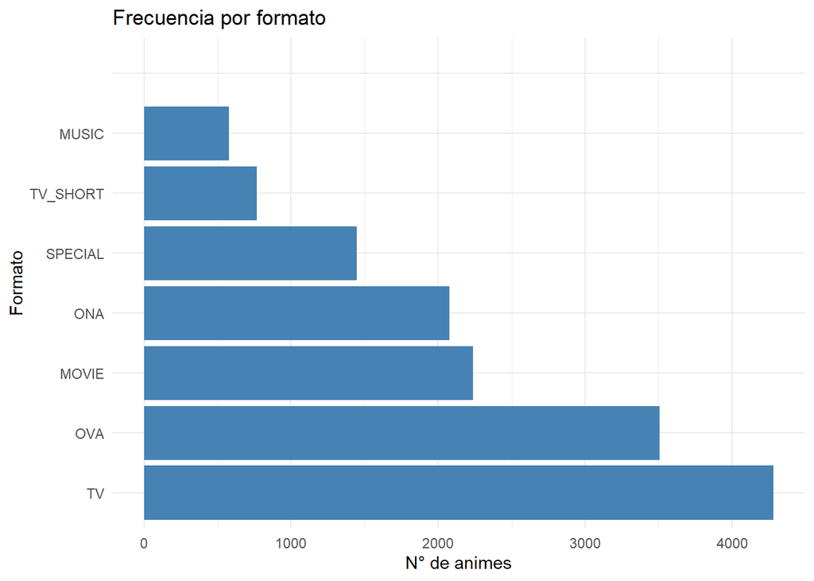

```r
Frecxform <- ggplot(anime_limpio, aes(x = fct_infreq(format))) +
  geom_bar(fill = "steelblue") + coord_flip() +
  labs(title = "Frecuencia por formato", x = "Formato", y = "N° de animes") +
  theme_minimal()
Frecxform
```

```r
anime_gen_long |>
  count(genero, sort = TRUE) |>
  slice_head(n = 15) |>
  kable(caption = "Top 15 géneros más frecuentes")
```

Top 15 géneros más frecuentes

| genero | n |
| --- | --- |
| Comedy | 5665 |
| Action | 4437 |
| Fantasy | 3690 |
| Adventure | 3116 |
| Drama | 2916 |
| Sci-Fi | 2663 |
| Romance | 2493 |
| Slice of Life | 2332 |
| Supernatural | 1679 |
| Hentai | 1593 |
| Mecha | 1051 |
| Ecchi | 951 |
| Mystery | 854 |
| Music | 752 |
| Sports | 750 |

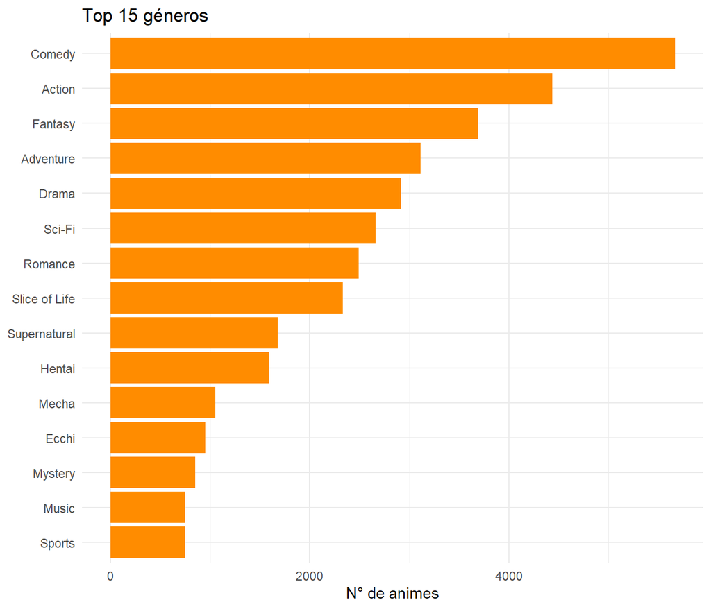

```r
top15 <- anime_gen_long |>
  count(genero, sort = TRUE) |>
  slice_head(n = 15) |>
  ggplot(aes(x = fct_reorder(genero, n), y = n)) +
  geom_col(fill = "darkorange") + coord_flip() +
  labs(title = "Top 15 géneros", x = NULL, y = "N° de animes") +
  theme_minimal()
top15
```

```r
metricas_gen <- anime_gen_long |>
  group_by(genero) |>
  summarise(n = n(),
            pop_mediana = median(popularity),
            score_medio = mean(averageScore)) |>
  filter(n >= 50)

metricas_gen |> arrange(desc(pop_mediana)) |> slice_head(n = 15) |>
  kable(caption = "Top 15 géneros por popularidad mediana (n ≥ 50)")
```

Top 15 géneros por popularidad mediana (n ≥ 50)

| genero | n | pop_mediana | score_medio |
| --- | --- | --- | --- |
| Thriller | 218 | 32866.5 | 68.14679 |
| Psychological | 683 | 11540.0 | 65.17423 |
| Mystery | 854 | 11176.0 | 67.07728 |
| Supernatural | 1679 | 9950.0 | 65.32817 |
| Ecchi | 951 | 9871.0 | 60.32808 |
| Drama | 2916 | 7957.5 | 66.31139 |
| Romance | 2493 | 7226.0 | 64.44846 |
| Slice of Life | 2332 | 5429.0 | 64.44082 |
| Action | 4437 | 5265.0 | 63.84922 |
| Horror | 503 | 4110.0 | 58.23062 |
| Sports | 750 | 3663.0 | 63.91600 |
| Comedy | 5665 | 3587.0 | 61.94740 |
| Sci-Fi | 2663 | 3295.0 | 62.12843 |
| Fantasy | 3690 | 3253.0 | 62.67236 |
| Mahou Shoujo | 427 | 2948.0 | 63.54098 |

```r
metricas_gen |> arrange(desc(score_medio)) |> slice_head(n = 15) |>
  kable(caption = "Top 15 géneros por score medio (n ≥ 50)")
```

Top 15 géneros por score medio (n ≥ 50)

| genero | n | pop_mediana | score_medio |
| --- | --- | --- | --- |
| Thriller | 218 | 32866.5 | 68.14679 |
| Mystery | 854 | 11176.0 | 67.07728 |
| Drama | 2916 | 7957.5 | 66.31139 |
| Supernatural | 1679 | 9950.0 | 65.32817 |
| Psychological | 683 | 11540.0 | 65.17423 |
| Romance | 2493 | 7226.0 | 64.44846 |
| Slice of Life | 2332 | 5429.0 | 64.44082 |
| Sports | 750 | 3663.0 | 63.91600 |
| Action | 4437 | 5265.0 | 63.84922 |
| Mahou Shoujo | 427 | 2948.0 | 63.54098 |
| Adventure | 3116 | 2785.0 | 62.95732 |
| Fantasy | 3690 | 3253.0 | 62.67236 |
| Sci-Fi | 2663 | 3295.0 | 62.12843 |
| Comedy | 5665 | 3587.0 | 61.94740 |
| Music | 752 | 2482.0 | 61.43750 |

```r
popvscal <- ggplot(anime_limpio, aes(x = log_popularity, y = averageScore)) +
  geom_point(alpha = 0.15, color = "purple") +
  geom_smooth(method = "lm", color = "red") +
  labs(title = "Popularidad (log) vs. Calificación",
       x = "log1p(Popularity)", y = "Average Score") +
  theme_minimal()

scorefor <- ggplot(anime_limpio, aes(x = format, y = averageScore, fill = format)) +
  geom_boxplot() + coord_flip() +
  labs(title = "Score por formato", x = NULL, y = "Average Score") +
  theme_minimal() + theme(legend.position = "none")

scoredur <- ggplot(anime_limpio, aes(x = tipo_duracion, y = averageScore, fill = tipo_duracion)) +
  geom_boxplot() +
  labs(title = "Score según duración", x = NULL, y = "Average Score") +
  theme_minimal() + theme(legend.position = "none")
```

```r
if(!dir.exists('graficos')) dir.create('graficos')

saveRDS(scoredur,'graficos/scoredur.rds')
saveRDS(scorefor,'graficos/scorefor.rds')
saveRDS(popvscal,'graficos/popvscal.rds')
saveRDS(top15,'graficos/top15.rds')
saveRDS(Frecxform,'graficos/frecxform.rds')
```

# Análisis de componentes principales (PCA)

El objetivo del PCA es resumir la información de las variables numéricas del conjunto de animes y facilitar la identificación de patrones. Para este análisis se utilizaron el número de episodios, la valoración promedio y la popularidad. Revisión de variables numéricas Primero se revisan las estadísticas descriptivas y los valores faltantes de las variables que serán utilizadas.

```r
# Resumen estadístico de las variables numéricas
summary(anime_limpio[, c( "episodes", "averageScore", "popularity" )])
```

```
##     episodes        averageScore     popularity
##  Min.   :   0.00   Min.   :16.00   Min.   :    107
##  1st Qu.:   1.00   1st Qu.:53.00   1st Qu.:    760
##  Median :   3.00   Median :61.00   Median :   2347
##  Mean   :  12.38   Mean   :60.77   Mean   :  20196
##  3rd Qu.:  12.00   3rd Qu.:69.00   3rd Qu.:  11616
##  Max.   :1818.00   Max.   :91.00   Max.   :1051019
```

```r
# Comprobar valores faltantes
colSums(is.na(anime_limpio[, c( "episodes", "averageScore", "popularity" )]))
```

```
##     episodes averageScore   popularity
##            0            0            0
```

# Revisión de formatos y géneros

También se revisa la distribución de los formatos y algunos registros de géneros para conocer la estructura de los datos.

```r
# Frecuencia de cada formato
table(anime_limpio$format)
```

```
##
##             MOVIE    MUSIC      ONA      OVA  SPECIAL       TV TV_SHORT
##        1     2239      580     2079     3507     1446     4281      766
```

```r
# Primeros registros de géneros
head(anime_limpio$genres_limpio, 20)
```

```
##  [1] "Action, Drama, Fantasy, Mystery"
##  [2] "Action, Adventure, Drama, Fantasy, Supernatural"
##  [3] "Action, Drama, Supernatural"
##  [4] "Mystery, Psychological, Supernatural, Thriller"
##  [5] "Action, Adventure, Comedy"
##  [6] "Action, Adventure, Fantasy"
##  [7] "Action, Comedy, Sci-Fi, Supernatural"
##  [8] "Action, Adventure, Comedy, Drama, Fantasy"
##  [9] "Action, Drama, Horror, Mystery, Psychological, Supernatural"
## [10] "Action, Drama, Fantasy, Mystery"
## [11] "Action, Adventure, Drama, Fantasy"
## [12] "Action, Adventure, Comedy, Drama, Fantasy, Supernatural"
## [13] "Action, Adventure, Fantasy, Romance"
## [14] "Drama, Romance, Slice of Life"
## [15] "Drama, Romance, Supernatural"
## [16] "Action, Drama, Fantasy, Mystery"
## [17] "Action, Adventure, Comedy"
## [18] "Action, Drama, Fantasy, Mystery"
## [19] "Drama, Fantasy, Horror, Mystery, Psychological, Thriller"
## [20] "Action, Drama, Horror, Supernatural"
```

# Transformación de variables

Las variables episodes y popularity presentan distribuciones asimétricas y valores extremos. Para reducir su influencia se aplica la transformación logarítmica log1p().

```r
# Crear una copia de la base para el análisis PCA
anime_pca <- anime_limpio
# Aplicar transformación logarítmica
anime_pca$log_popularity <- log1p(anime_pca$popularity)
anime_pca$log_episodes <- log1p(anime_pca$episodes)
# Eliminar registros sin información sobre episodios
anime_pca <- anime_pca[!is.na(anime_pca$episodes), ]
# Comprobar nuevamente los valores faltantes
colSums(is.na(anime_pca[, c( "log_episodes", "averageScore", "log_popularity" )]))
```

```
##   log_episodes   averageScore log_popularity
##              0              0              0
```

# Distribución de las variables

Se comparan las distribuciones originales y transformadas para observar el efecto de log1p().

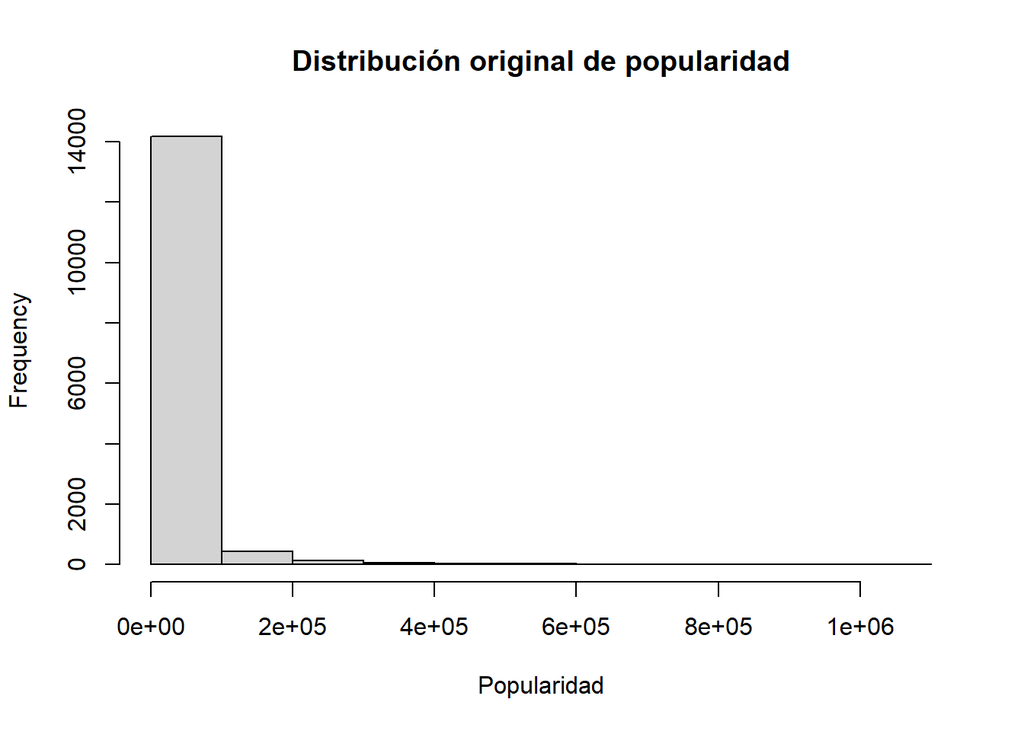

```r
# Distribución original de popularidad
hist(
  anime_limpio$popularity,
  main = "Distribución original de popularidad",
  xlab = "Popularidad"
)
```

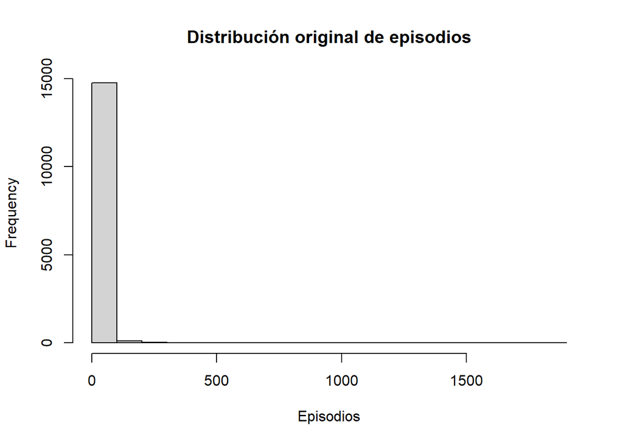

```r
# Distribución original de episodios
hist(
  anime_limpio$episodes,
  main = "Distribución original de episodios",
  xlab = "Episodios"
)
```

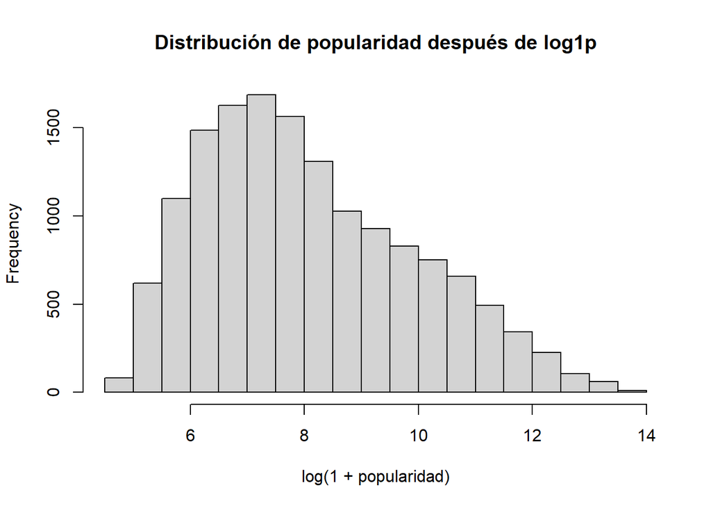

```r
# Distribución transformada de popularidad
hist(
  anime_pca$log_popularity,
  main = "Distribución de popularidad después de log1p",
  xlab = "log(1 + popularidad)"
)
```

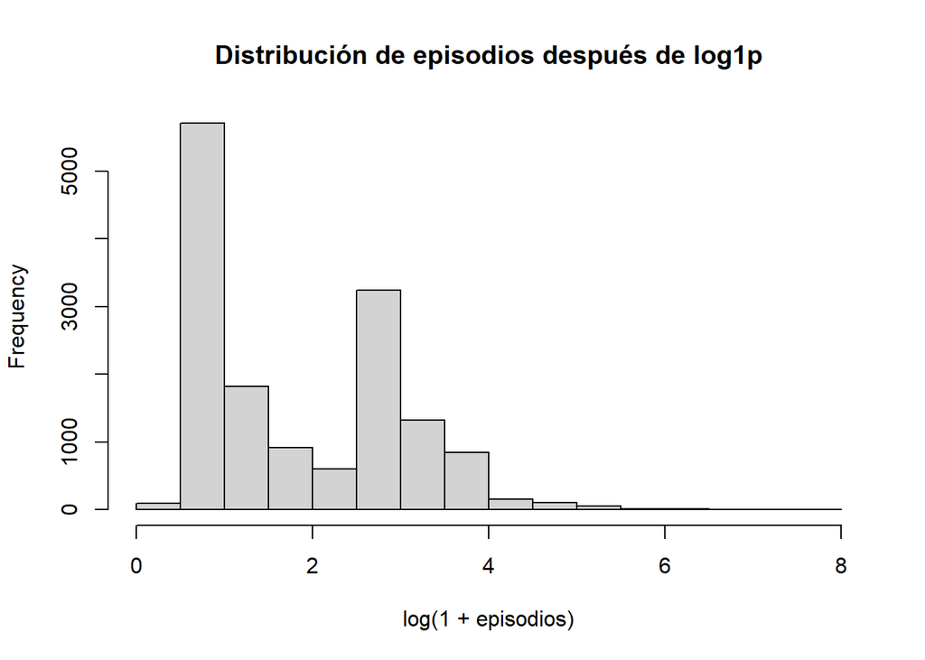

```r
# Distribución transformada de episodios
hist(
  anime_pca$log_episodes,
  main = "Distribución de episodios después de log1p",
  xlab = "log(1 + episodios)"
)
```

La transformación permite reducir la asimetría de las variables de episodios y popularidad, haciendo más adecuada su utilización en el análisis multivariado.

# Preparación de los datos para PCA

Para el PCA se utilizan las tres variables cuantitativas transformadas. Las variables identificadoras y las variables categóricas se reservan para etapas posteriores.

```r
# Seleccionar las variables para el PCA
datos_pca <- anime_pca[, c( "log_episodes", "averageScore", "log_popularity" )]
head(datos_pca)
```

```
##   log_episodes averageScore log_popularity
## 1     3.258097           85       13.86527
## 2     3.295837           83       13.80673
## 3     3.218876           84       13.78401
## 4     3.637586           84       13.77314
## 5     2.639057           77       13.67816
## 6     5.003946           89       13.63924
```

# Aplicación del PCA

Se aplica prcomp() con centrado y estandarización. Esto evita que las diferentes escalas de las variables influyan de manera desproporcionada en los componentes.

```r
# Ejecutar PCA
pca <- prcomp( datos_pca, center = TRUE, scale. = TRUE )
summary(pca)
```

```
## Importance of components:
##                           PC1    PC2     PC3
## Standard deviation     1.3662 0.9275 0.52283
## Proportion of Variance 0.6221 0.2867 0.09112
## Cumulative Proportion  0.6221 0.9089 1.00000
```

# Cargas de los componentes

Las cargas permiten identificar qué variables contribuyen principalmente a cada componente.

```r
# Cargas de las variables en cada componente
pca$rotation[, 1:3]
```

```
##                       PC1        PC2         PC3
## log_episodes   -0.3741764 -0.9263691  0.04280601
## averageScore   -0.6511489  0.2953163  0.69913765
## log_popularity -0.6603008  0.2337277 -0.71370455
```

PC1 está asociado principalmente con averageScore y log_popularity, mientras que PC2 está fuertemente dominado por log_episodes. Por lo tanto, PC1 representa principalmente una dimensión relacionada con valoración y popularidad, mientras que PC2 representa principalmente una dimensión relacionada con la duración.

```r
# Desviación estándar de los componentes
pca$sdev
```

```
## [1] 1.3661832 0.9274642 0.5228323
```

```r
# Coordenadas de los primeros 10 animes
pca$x[1:10, ]
```

```
##          PC1        PC2        PC3
## 1  -3.989868  0.2141666 -0.6308527
## 2  -3.861813  0.1222891 -0.7349491
## 3  -3.888376  0.2083270 -0.6649460
## 4  -4.020403 -0.1295530 -0.6451899
## 5  -3.244542  0.4714414 -1.0940431
## 6  -4.714399 -1.1092860 -0.2222821
## 7  -3.531947  0.6768954 -0.6619908
## 8  -2.929904  2.8436340 -0.4921621
## 9  -3.101230  0.4828450 -1.0964707
## 10 -3.635240  0.7253409 -0.5164865
```

# Visualización del espacio PCA

Se representan los animes utilizando PC1 y PC2, que concentran la mayor parte de la información del PCA.

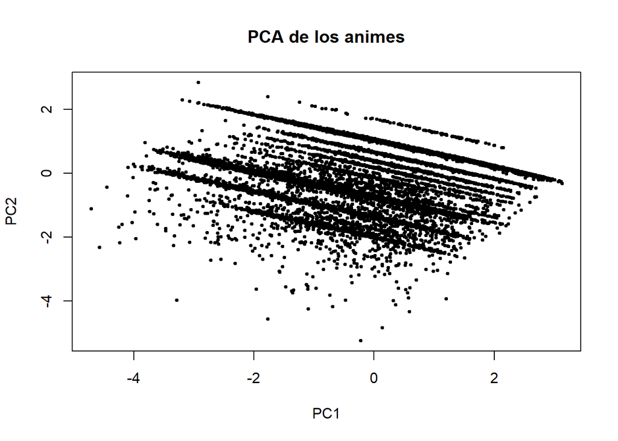

```r
# Visualizar los animes en el espacio PC1-PC2
plot( pca$x[, 1], pca$x[, 2], xlab = "PC1", ylab = "PC2", main = "PCA de los animes", pch = 19, cex = 0.5 )
```

La representación permite observar la distribución general de los animes en las dos principales dimensiones obtenidas.

# Análisis según formato

Para explorar posibles diferencias entre formatos, primero se convierten los valores vacíos en NA.

```r
# Convertir formatos vacíos en NA
anime_pca$format[anime_pca$format == ""] <- NA
# Revisar las categorías de formato
table(anime_pca$format, useNA = "ifany")
```

```
##
##             MOVIE    MUSIC      ONA      OVA  SPECIAL       TV TV_SHORT     <NA>
##        0     2239      580     2079     3507     1446     4281      766        1
```

Se identifican los registros que cuentan con un formato válido.

```r
# Identificar registros con formato válido
filas_validas <- !is.na(anime_pca$format)
# Comprobar el número de observaciones
sum(filas_validas)
```

```
## [1] 14898
```

```r
nrow(pca$x)
```

```
## [1] 14899
```

Posteriormente se visualizan los formatos dentro del espacio PCA.

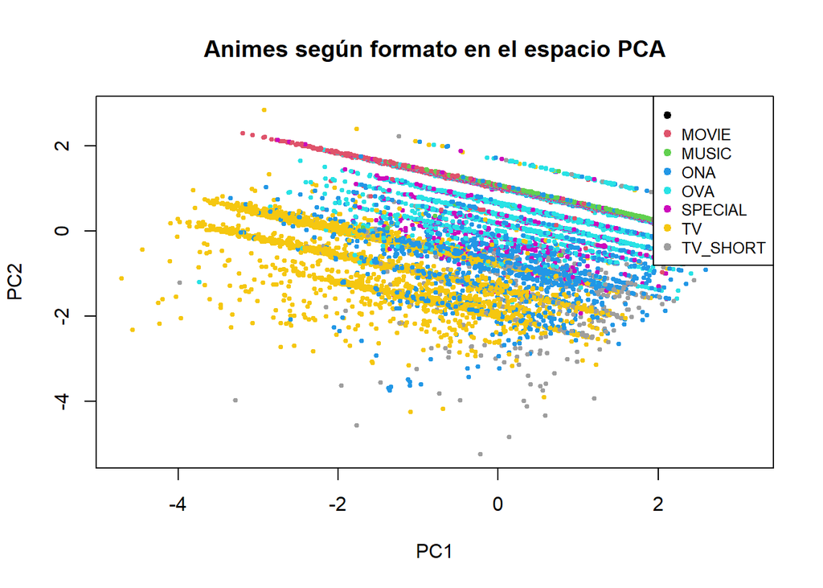

```r
# PCA coloreado según formato
plot( pca$x[filas_validas, 1], pca$x[filas_validas, 2], xlab = "PC1", ylab = "PC2", main = "Animes según formato en el espacio PCA", pch = 19, cex = 0.5, col = as.factor(anime_pca$format[filas_validas]) )
# Agregar leyenda
legend( "topright", legend = levels(as.factor( anime_pca$format[filas_validas] )), col = 1:length(levels(as.factor( anime_pca$format[filas_validas] ))), pch = 19, cex = 0.8 )
```

# Análisis de géneros

Debido a que un anime puede pertenecer a varios géneros, estos se transforman en indicadores binarios de presencia o ausencia. # Frecuencia de géneros Primero se identifican los géneros más frecuentes.

```r
library(dplyr)
library(tidyr)

# Separar los géneros en filas
generos_separados <- anime_pca %>%
  filter(!is.na(genres_limpio)) %>%
  separate_rows(genres_limpio, sep = ",\\s*") %>%
  count(genres_limpio, sort = TRUE)

# Mostrar los 20 géneros más frecuentes
head(generos_separados, 20)
```

```
## # A tibble: 19 × 2
##    genres_limpio     n
##    <chr>         <int>
##  1 Comedy         5665
##  2 Action         4437
##  3 Fantasy        3690
##  4 Adventure      3116
##  5 Drama          2916
##  6 Sci-Fi         2663
##  7 Romance        2493
##  8 Slice of Life  2332
##  9 Supernatural   1679
## 10 Hentai         1593
## 11 Mecha          1051
## 12 Ecchi           951
## 13 Mystery         854
## 14 Music           752
## 15 Sports          750
## 16 Psychological   683
## 17 Horror          503
## 18 Mahou Shoujo    427
## 19 Thriller        218
```

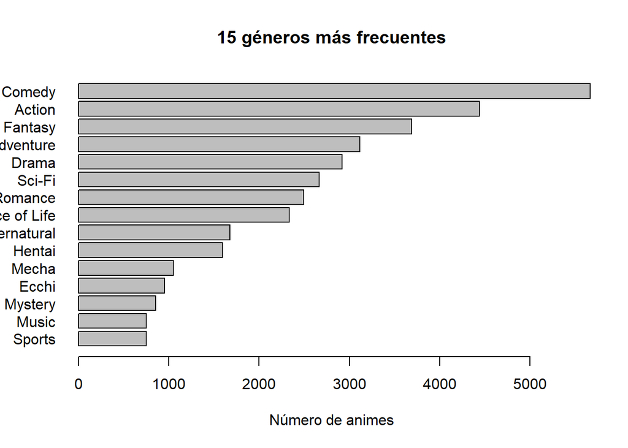

```r
#Se visualizan los 15 géneros con mayor frecuencia.

# Seleccionar los 15 géneros más frecuentes
top_generos <- generos_separados %>%
  slice_max(order_by = n, n = 15) %>%
  arrange(n)

# Gráfico de frecuencia
barplot(
  top_generos$n,
  names.arg = top_generos$genres_limpio,
  horiz = TRUE,
  las = 1,
  main = "15 géneros más frecuentes",
  xlab = "Número de animes"
)
```

```r
#Para el análisis posterior se seleccionan los diez géneros más frecuentes.

# Seleccionar los 10 géneros más frecuentes
top_10_generos <- generos_separados %>%
  slice_max(order_by = n, n = 10)

top_10_generos
```

```
## # A tibble: 10 × 2
##    genres_limpio     n
##    <chr>         <int>
##  1 Comedy         5665
##  2 Action         4437
##  3 Fantasy        3690
##  4 Adventure      3116
##  5 Drama          2916
##  6 Sci-Fi         2663
##  7 Romance        2493
##  8 Slice of Life  2332
##  9 Supernatural   1679
## 10 Hentai         1593
```

# Creación de indicadores binarios

Cada género se convierte en una columna donde 1 indica presencia y 0 ausencia.

```r
# Crear indicadores binarios para los 10 géneros más frecuentes
generos_binarios <- anime_pca %>%
  select(id, genres_limpio) %>%
  filter(!is.na(genres_limpio)) %>%
  separate_rows(genres_limpio, sep = ",\\s*") %>%
  filter(genres_limpio %in% top_10_generos$genres_limpio) %>%
  mutate(presente = 1) %>%
  distinct(id, genres_limpio, .keep_all = TRUE) %>%
  pivot_wider(
    names_from = genres_limpio,
    values_from = presente,
    values_fill = 0
  )

head(generos_binarios)
```

```
## # A tibble: 6 × 11
##       id Action Drama Fantasy Adventure Supernatural Comedy `Sci-Fi` Romance `Slice of Life`
##    <int>  <dbl> <dbl>   <dbl>     <dbl>        <dbl>  <dbl>    <dbl>   <dbl>           <dbl>
## 1  16498      1     1       1         0            0      0        0       0               0
## 2 101922      1     1       1         1            1      0        0       0               0
## 3 113415      1     1       0         0            1      0        0       0               0
## 4   1535      0     0       0         0            1      0        0       0               0
## 5  21459      1     0       0         1            0      1        0       0               0
## 6  11061      1     0       1         1            0      0        0       0               0
## # ℹ 1 more variable: Hentai <dbl>
```

```r
# Revisar dimensiones
dim(generos_binarios)
```

```
## [1] 14174    11
```

```r
# Revisar frecuencia de cada género
colSums(generos_binarios[, -1])
```

```
##        Action         Drama       Fantasy     Adventure  Supernatural        Comedy
##          4437          2916          3690          3116          1679          5665
##        Sci-Fi       Romance Slice of Life        Hentai
##          2663          2493          2332          1593
```

# Relación entre géneros y PCA

Se combinan las coordenadas del PCA con los indicadores de género.

```r
# Convertir las coordenadas del PCA en una tabla
coordenadas_pca <- as.data.frame(pca$x) %>%
  mutate(id = anime_pca$id)

# Unir coordenadas y géneros
anime_pca_generos <- coordenadas_pca %>%
  left_join(generos_binarios, by = "id")

# Revisar el resultado
head(anime_pca_generos)
```

```
##         PC1        PC2        PC3     id Action Drama Fantasy Adventure Supernatural Comedy
## 1 -3.989868  0.2141666 -0.6308527  16498      1     1       1         0            0      0
## 2 -3.861813  0.1222891 -0.7349491 101922      1     1       1         1            1      0
## 3 -3.888376  0.2083270 -0.6649460 113415      1     1       0         0            1      0
## 4 -4.020403 -0.1295530 -0.6451899   1535      0     0       0         0            1      0
## 5 -3.244542  0.4714414 -1.0940431  21459      1     0       0         1            0      1
## 6 -4.714399 -1.1092860 -0.2222821  11061      1     0       1         1            0      0
##   Sci-Fi Romance Slice of Life Hentai
## 1      0       0             0      0
## 2      0       0             0      0
## 3      0       0             0      0
## 4      0       0             0      0
## 5      0       0             0      0
## 6      0       0             0      0
```

```r
# Revisar dimensiones
dim(anime_pca_generos)
```

```
## [1] 14899    14
```

```r
# Revisar valores faltantes en las coordenadas PCA
colSums(
  is.na(
    anime_pca_generos[, c(
      "PC1",
      "PC2",
      "PC3"
    )]
  )
)
```

```
## PC1 PC2 PC3
##   0   0   0
```

```r
#Se calcula la posición promedio de cada género dentro del espacio PC1-PC2.

# Calcular posición promedio de cada género
resultados_generos <- data.frame(
  genero = names(generos_binarios)[-1]
)

resultados_generos$n <- sapply(
  resultados_generos$genero,
  function(g) {
    sum(generos_binarios[[g]] == 1)
  }
)

resultados_generos$PC1_promedio <- sapply(
  resultados_generos$genero,
  function(g) {
    mean(
      anime_pca_generos$PC1[
        anime_pca_generos[[g]] == 1
      ],
      na.rm = TRUE
    )
  }
)

resultados_generos$PC2_promedio <- sapply(
  resultados_generos$genero,
  function(g) {
    mean(
      anime_pca_generos$PC2[
        anime_pca_generos[[g]] == 1
      ],
      na.rm = TRUE
    )
  }
)

resultados_generos
```

```
##           genero    n PC1_promedio  PC2_promedio
## 1         Action 4437   -0.4751740 -0.0063428315
## 2          Drama 2916   -0.6934495  0.1922680030
## 3        Fantasy 3690   -0.2847410 -0.0606917906
## 4      Adventure 3116   -0.2947326 -0.1557798007
## 5   Supernatural 1679   -0.7051716  0.1465349003
## 6         Comedy 5665   -0.2567979 -0.1362288040
## 7         Sci-Fi 2663   -0.2013620  0.0007265361
## 8        Romance 2493   -0.6160635  0.1012021653
## 9  Slice of Life 2332   -0.4760270  0.0163088254
## 10        Hentai 1593    0.9020261  0.3111373197
```

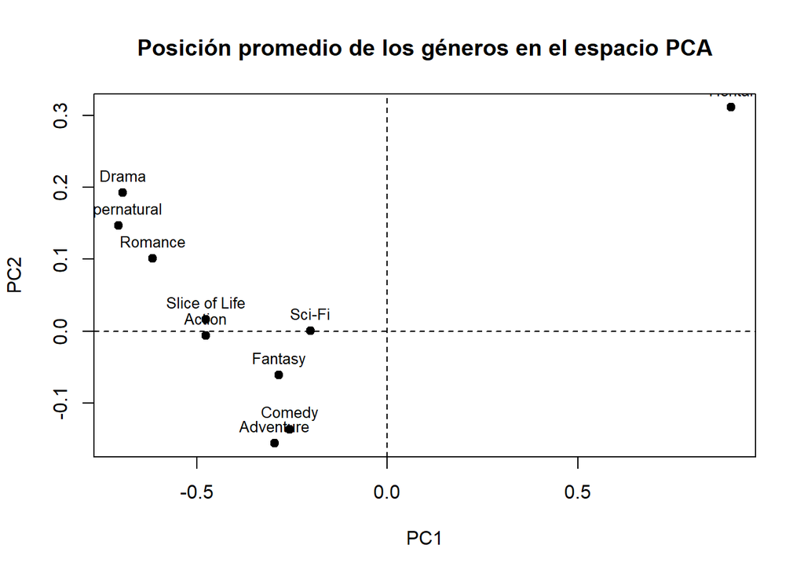

```r
# Visualizar la posición promedio de los géneros
plot(
  resultados_generos$PC1_promedio,
  resultados_generos$PC2_promedio,
  pch = 19,
  xlab = "PC1",
  ylab = "PC2",
  main = "Posición promedio de los géneros en el espacio PCA"
)

text(
  resultados_generos$PC1_promedio,
  resultados_generos$PC2_promedio,
  labels = resultados_generos$genero,
  pos = 3,
  cex = 0.8
)

abline(
  h = 0,
  v = 0,
  lty = 2
)
```

Los géneros presentan posiciones promedio diferentes dentro del espacio PCA. Esto indica que algunos géneros muestran tendencias distintas respecto a las dimensiones asociadas con valoración, popularidad y duración. Sin embargo, existe superposición entre ellos, por lo que estas diferencias deben interpretarse como tendencias y no como grupos completamente separados.

# Proceso de clustering

Después del PCA se realiza un análisis de clustering para identificar agrupaciones considerando simultáneamente las variables numéricas, los géneros y los formatos.

# Preparación de los formatos

Los formatos se convierten en indicadores binarios.

```r
# Crear indicadores binarios para el formato
format_binario <- anime_pca %>% filter(!is.na(format)) %>% select(id, format) %>% mutate(presente = 1) %>% pivot_wider( names_from = format, values_from = presente, values_fill = 0 )
# Revisar resultado
head(format_binario)
```

```
## # A tibble: 6 × 8
##       id    TV MOVIE   ONA TV_SHORT SPECIAL   OVA MUSIC
##    <int> <dbl> <dbl> <dbl>    <dbl>   <dbl> <dbl> <dbl>
## 1  16498     1     0     0        0       0     0     0
## 2 101922     1     0     0        0       0     0     0
## 3 113415     1     0     0        0       0     0     0
## 4   1535     1     0     0        0       0     0     0
## 5  21459     1     0     0        0       0     0     0
## 6  11061     1     0     0        0       0     0     0
```

```r
# Revisar cantidad de animes por formato
colSums(format_binario[, -1])
```

```
##       TV    MOVIE      ONA TV_SHORT  SPECIAL      OVA    MUSIC
##     4281     2239     2079      766     1446     3507      580
```

# Construcción de la matriz de clustering

Se conservan únicamente los registros que cuentan con información suficiente de géneros y formato.

```r
# Construir la base final para clustering
datos_clustering <- anime_pca %>% select( id, log_episodes, averageScore, log_popularity ) %>% inner_join( generos_binarios, by = "id" ) %>% inner_join( format_binario, by = "id" )
# Revisar dimensiones
dim(datos_clustering)
```

```
## [1] 14174    21
```

```r
# Revisar primeras filas
head(datos_clustering)
```

```
##       id log_episodes averageScore log_popularity Action Drama Fantasy Adventure Supernatural
## 1  16498     3.258097           85       13.86527      1     1       1         0            0
## 2 101922     3.295837           83       13.80673      1     1       1         1            1
## 3 113415     3.218876           84       13.78401      1     1       0         0            1
## 4   1535     3.637586           84       13.77314      0     0       0         0            1
## 5  21459     2.639057           77       13.67816      1     0       0         1            0
## 6  11061     5.003946           89       13.63924      1     0       1         1            0
##   Comedy Sci-Fi Romance Slice of Life Hentai TV MOVIE ONA TV_SHORT SPECIAL OVA MUSIC
## 1      0      0       0             0      0  1     0   0        0       0   0     0
## 2      0      0       0             0      0  1     0   0        0       0   0     0
## 3      0      0       0             0      0  1     0   0        0       0   0     0
## 4      0      0       0             0      0  1     0   0        0       0   0     0
## 5      1      0       0             0      0  1     0   0        0       0   0     0
## 6      0      0       0             0      0  1     0   0        0       0   0     0
```

La variable id únicamente identifica cada anime, por lo que se excluye de la matriz utilizada por k-means.

```r
# Crear matriz de variables para clustering
matriz_clustering <- datos_clustering %>% select(-id)
# Comprobar valores faltantes
colSums(is.na(matriz_clustering))
```

```
##   log_episodes   averageScore log_popularity         Action          Drama        Fantasy
##              0              0              0              0              0              0
##      Adventure   Supernatural         Comedy         Sci-Fi        Romance  Slice of Life
##              0              0              0              0              0              0
##         Hentai             TV          MOVIE            ONA       TV_SHORT        SPECIAL
##              0              0              0              0              0              0
##            OVA          MUSIC
##              0              0
```

#Estandarización

Las variables se estandarizan para evitar que las diferencias de escala tengan una influencia desproporcionada en el cálculo de las distancias.

```r
# Estandarizar las variables
matriz_clustering_scaled <- scale(matriz_clustering)
# Revisar primeras filas
head(matriz_clustering_scaled)
```

```
##      log_episodes averageScore log_popularity     Action     Drama    Fantasy  Adventure
## [1,]     1.249859     2.214326       3.097646  1.4813325  1.964814  1.6855242 -0.5308174
## [2,]     1.282625     2.029520       3.065968  1.4813325  1.964814  1.6855242  1.8837543
## [3,]     1.215807     2.121923       3.053678  1.4813325  1.964814 -0.5932454 -0.5308174
## [4,]     1.579334     2.121923       3.047794 -0.6750203 -0.508918 -0.5932454 -0.5308174
## [5,]     0.712405     1.475102       2.996402  1.4813325 -0.508918 -0.5932454  1.8837543
## [6,]     2.765617     2.583937       2.975348  1.4813325 -0.508918  1.6855242  1.8837543
##      Supernatural     Comedy     Sci-Fi    Romance Slice of Life     Hentai       TV      MOVIE
## [1,]   -0.3665573 -0.8159159 -0.4809653 -0.4619615     -0.443748 -0.3558238 1.554108 -0.4141131
## [2,]    2.7278938 -0.8159159 -0.4809653 -0.4619615     -0.443748 -0.3558238 1.554108 -0.4141131
## [3,]    2.7278938 -0.8159159 -0.4809653 -0.4619615     -0.443748 -0.3558238 1.554108 -0.4141131
## [4,]    2.7278938 -0.8159159 -0.4809653 -0.4619615     -0.443748 -0.3558238 1.554108 -0.4141131
## [5,]   -0.3665573  1.2255301 -0.4809653 -0.4619615     -0.443748 -0.3558238 1.554108 -0.4141131
## [6,]   -0.3665573 -0.8159159 -0.4809653 -0.4619615     -0.443748 -0.3558238 1.554108 -0.4141131
##           ONA  TV_SHORT    SPECIAL        OVA      MUSIC
## [1,] -0.40176 -0.234859 -0.3265648 -0.5645658 -0.1802389
## [2,] -0.40176 -0.234859 -0.3265648 -0.5645658 -0.1802389
## [3,] -0.40176 -0.234859 -0.3265648 -0.5645658 -0.1802389
## [4,] -0.40176 -0.234859 -0.3265648 -0.5645658 -0.1802389
## [5,] -0.40176 -0.234859 -0.3265648 -0.5645658 -0.1802389
## [6,] -0.40176 -0.234859 -0.3265648 -0.5645658 -0.1802389
```

En este análisis se utiliza k-means sobre una combinación de variables numéricas y binarias. Por ello, los resultados representan agrupaciones obtenidas bajo esta representación de los datos y no categorías naturales o definitivas.

#Selección del número de clusters